# Reproducible Research: Peer Assessment 1

## Initialization

Start by setting up the parameters for external figures.

```r
library(knitr)
opts_chunk$set(dev="png", fig.path="figure/")
```

## Loading and preprocessing the data

Unzip and load the data from a .csv file.

```r
unzip("activity.zip")
activity.data <- read.csv("activity.csv")
```

Check a short summary of what have been read.

```r
str(activity.data)
```

```
## 'data.frame':    17568 obs. of  3 variables:
##  $ steps   : int  NA NA NA NA NA NA NA NA NA NA ...
##  $ date    : Factor w/ 61 levels "2012-10-01","2012-10-02",..: 1 1 1 1 1 1 1 1 1 1 ...
##  $ interval: int  0 5 10 15 20 25 30 35 40 45 ...
```

The date column will be transformed to Date object so that it can be treated correctly in plots.

```r
activity.data$date <- as.Date(activity.data$date, format = "%Y-%m-%d")
```

## What is mean total number of steps taken per day?

Use *tapply* to calculate the number of steps taken each day.

```r
activity.data.dailysums <- tapply(activity.data$steps, activity.data$date, sum, na.rm = TRUE)
head(activity.data.dailysums)
```

```
## 2012-10-01 2012-10-02 2012-10-03 2012-10-04 2012-10-05 2012-10-06
##          0        126      11352      12116      13294      15420
```

Plot a histogram with ggplot2 showing the distribution of daily step count.

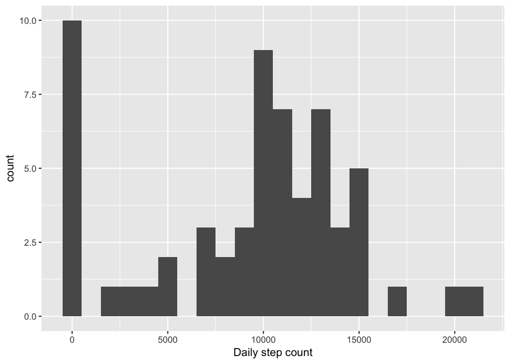

```r
library(ggplot2)
qplot(activity.data.dailysums, binwidth=1000, xlab="Daily step count")
```

Calculate the mean and median using the *summary* function.

```r
summary(activity.data.dailysums)
```

```
##    Min. 1st Qu.  Median    Mean 3rd Qu.    Max.
##       0    6778   10400    9354   12810   21190
```

## What is the average daily activity pattern?

Use *ddply* function of the *plyr* library to calculate the mean and median values of each interval across all days: split by interval, apply mean & median, and combine to a data frame.

```r
library(plyr)
activity.data.daily.activity <- ddply(activity.data, c("interval"), summarize,
                                      mean = round(mean(steps, na.rm=TRUE), 2),
                                      median = round(median(steps, na.rm=TRUE), 2))
```

Plot the daily activity pattern.

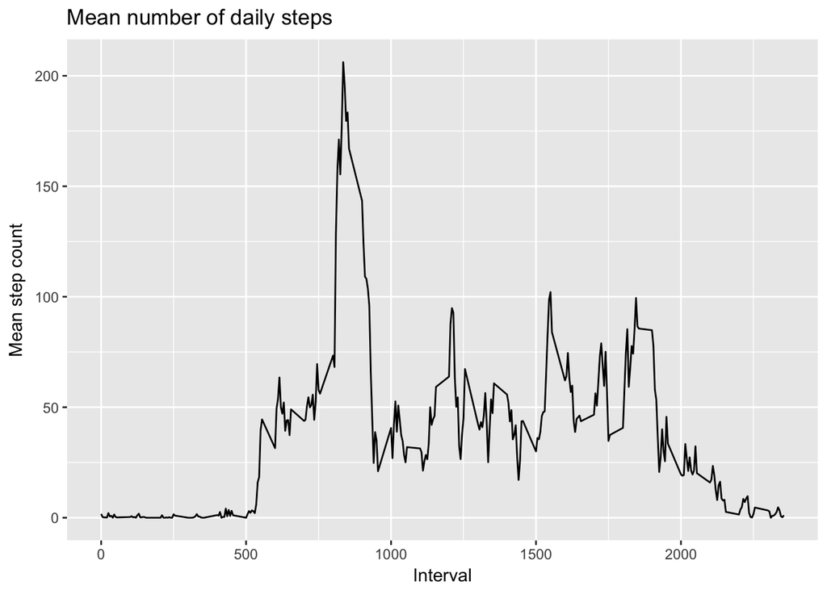

```r
ggplot(activity.data.daily.activity, aes(x = activity.data.daily.activity$interval,
                                         y = activity.data.daily.activity$mean)) +
        geom_line() + labs(title="Mean number of daily steps", x = "Interval", y = "Mean step count")
```

Calculate the maximum activity interval.

```r
activity.data.daily.activity[which.max(activity.data.daily.activity$mean), "interval"]
```

```
## [1] 835
```

## Imputing missing values

Calculate the total number of missing values with *complete.cases* function that returns a binary vector of all the rows that have none NA’s. Substract the length of that vector from the number of rows in the original data.

```r
nrow(activity.data) - sum(complete.cases(activity.data))
```

```
## [1] 2304
```

Fill the missing values with the mean step count of that interval.

```r
activity.data.complete <- ddply(activity.data, c("interval"), function(x) {
        missing <- is.na(x$steps)
        x[missing, "steps"] = mean(x[, "steps"], na.rm=TRUE)
        x
})
```

Now calculate the daily step count with the data set that has missing values imputed.

```r
activity.data.complete.dailysums <- tapply(activity.data.complete$steps, activity.data.complete$date, sum, na.rm = TRUE)
head(activity.data.complete.dailysums)
```

```
## 2012-10-01 2012-10-02 2012-10-03 2012-10-04 2012-10-05 2012-10-06
##   10766.19     126.00   11352.00   12116.00   13294.00   15420.00
```

Plot a histogram of the data.

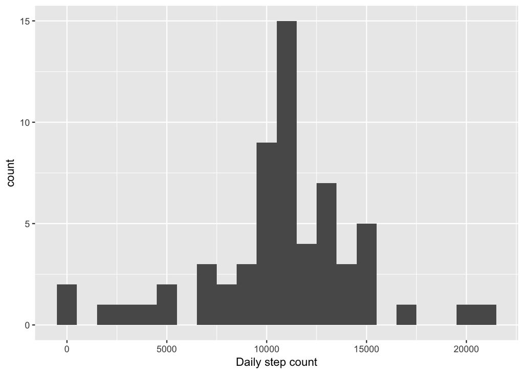

```r
qplot(activity.data.complete.dailysums, binwidth=1000, xlab="Daily step count")
```

The mean and median step counts can be viewed with the *summary* function.

```r
summary(activity.data.complete.dailysums)
```

```
##    Min. 1st Qu.  Median    Mean 3rd Qu.    Max.
##      41    9819   10770   10770   12810   21190
```

## Are there differences in activity patterns between weekdays and weekends?

Construct a new column (*part.of.the.week*) based on lookup-table. The date format can be transformed to literal weekday with the *weekdays* function. The literal weekday will be used as an index pointer to the lookup-table.

```r
part.of.the.week.lookup <- cbind(
        c("Monday", "Tuesday", "Wednesday", "Thursday", "Friday", "Saturday", "Sunday"),
        c("Weekday","Weekday","Weekday","Weekday","Weekday","Weekend","Weekend"))

activity.data.complete$part.of.the.week <- part.of.the.week.lookup[
        match(weekdays(activity.data.complete$date), part.of.the.week.lookup[,1])
        , 2]
```

Now calculate the mean step count of each interval across all days with the complete data set.

```r
activity.data.complete.mean.intervals <- ddply(activity.data.complete, c( "interval", "part.of.the.week"),
                                               summarize,
                                               meansteps = mean(steps, na.rm = TRUE)
)
```

Using ggplot’s facets function, it is now easy to separate the data with *part.of.the.week* variable.

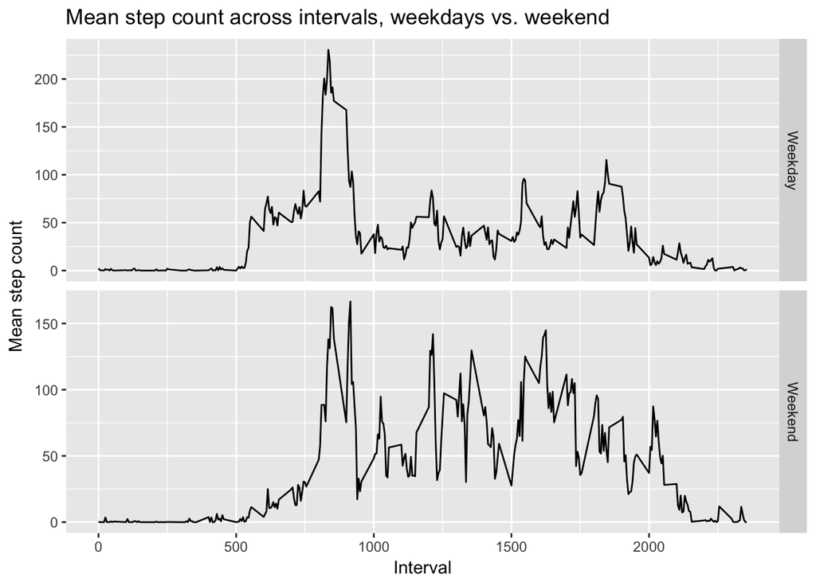

```r
ggplot(activity.data.complete.mean.intervals) +
        geom_line(aes(y = meansteps, x = interval), stat="identity") +
        labs(title="Mean step count across intervals, weekdays vs. weekend",
             x = "Interval",
             y = "Mean step count") +
        facet_grid(facets = part.of.the.week ~ ., scales="free")
```